# LoanTap Logistic Regression Business Case

```python
import numpy as np
import pandas as pd
import seaborn as sns
import matplotlib.pyplot as plt
```

```python
! pip install stats
! pip install scipy
! pip install statsmodels
! pip install scikit-learn
```

```python
from scipy.stats import chi2 # Distribution (cdf etc.)
from scipy.stats import chisquare # Statistical test (chistat, pvalue)
from scipy.stats import chi2_contingency # Categorical Vs Categorical
from scipy.stats import ttest_rel,ttest_1samp,ttest_ind
from scipy.stats import binom,tiecorrect
from scipy.stats import f,f_oneway
from scipy.stats import f,f_oneway,kruskal,ttest_ind,levene,shapiro,kstest,norm
from statsmodels.distributions.empirical_distribution import ECDF
from statsmodels.graphics.gofplots import qqplot
import stats
```

```python
df=pd.read_csv("logistic_regression.csv")
df
```

|  | loan_amnt | term | int_rate | installment | grade | sub_grade | emp_title | emp_length | home_ownership | annual_inc | ... | open_acc | pub_rec | revol_bal | revol_util | total_acc | initial_list_status | application_type | mort_acc | pub_rec_bankruptcies | address |
| --- | --- | --- | --- | --- | --- | --- | --- | --- | --- | --- | --- | --- | --- | --- | --- | --- | --- | --- | --- | --- | --- |
| 0 | 10000.0 | 36 months | 11.44 | 329.48 | B | B4 | Marketing | 10+ years | RENT | 117000.0 | ... | 16.0 | 0.0 | 36369.0 | 41.8 | 25.0 | w | INDIVIDUAL | 0.0 | 0.0 | 0174 Michelle Gateway\r\nMendozaberg, OK 22690 |
| 1 | 8000.0 | 36 months | 11.99 | 265.68 | B | B5 | Credit analyst | 4 years | MORTGAGE | 65000.0 | ... | 17.0 | 0.0 | 20131.0 | 53.3 | 27.0 | f | INDIVIDUAL | 3.0 | 0.0 | 1076 Carney Fort Apt. 347\r\nLoganmouth, SD 05113 |
| 2 | 15600.0 | 36 months | 10.49 | 506.97 | B | B3 | Statistician | < 1 year | RENT | 43057.0 | ... | 13.0 | 0.0 | 11987.0 | 92.2 | 26.0 | f | INDIVIDUAL | 0.0 | 0.0 | 87025 Mark Dale Apt. 269\r\nNew Sabrina, WV 05113 |
| 3 | 7200.0 | 36 months | 6.49 | 220.65 | A | A2 | Client Advocate | 6 years | RENT | 54000.0 | ... | 6.0 | 0.0 | 5472.0 | 21.5 | 13.0 | f | INDIVIDUAL | 0.0 | 0.0 | 823 Reid Ford\r\nDelacruzside, MA 00813 |
| 4 | 24375.0 | 60 months | 17.27 | 609.33 | C | C5 | Destiny Management Inc. | 9 years | MORTGAGE | 55000.0 | ... | 13.0 | 0.0 | 24584.0 | 69.8 | 43.0 | f | INDIVIDUAL | 1.0 | 0.0 | 679 Luna Roads\r\nGreggshire, VA 11650 |
| ... | ... | ... | ... | ... | ... | ... | ... | ... | ... | ... | ... | ... | ... | ... | ... | ... | ... | ... | ... | ... | ... |
| 396025 | 10000.0 | 60 months | 10.99 | 217.38 | B | B4 | licensed bankere | 2 years | RENT | 40000.0 | ... | 6.0 | 0.0 | 1990.0 | 34.3 | 23.0 | w | INDIVIDUAL | 0.0 | 0.0 | 12951 Williams Crossing\r\nJohnnyville, DC 30723 |
| 396026 | 21000.0 | 36 months | 12.29 | 700.42 | C | C1 | Agent | 5 years | MORTGAGE | 110000.0 | ... | 6.0 | 0.0 | 43263.0 | 95.7 | 8.0 | f | INDIVIDUAL | 1.0 | 0.0 | 0114 Fowler Field Suite 028\r\nRachelborough, ... |
| 396027 | 5000.0 | 36 months | 9.99 | 161.32 | B | B1 | City Carrier | 10+ years | RENT | 56500.0 | ... | 15.0 | 0.0 | 32704.0 | 66.9 | 23.0 | f | INDIVIDUAL | 0.0 | 0.0 | 953 Matthew Points Suite 414\r\nReedfort, NY 7... |
| 396028 | 21000.0 | 60 months | 15.31 | 503.02 | C | C2 | Gracon Services, Inc | 10+ years | MORTGAGE | 64000.0 | ... | 9.0 | 0.0 | 15704.0 | 53.8 | 20.0 | f | INDIVIDUAL | 5.0 | 0.0 | 7843 Blake Freeway Apt. 229\r\nNew Michael, FL... |
| 396029 | 2000.0 | 36 months | 13.61 | 67.98 | C | C2 | Internal Revenue Service | 10+ years | RENT | 42996.0 | ... | 3.0 | 0.0 | 4292.0 | 91.3 | 19.0 | f | INDIVIDUAL | NaN | 0.0 | 787 Michelle Causeway\r\nBriannaton, AR 48052 |

396030 rows × 27 columns

# 1.Define Problem Statement and perform Exploratory Data Analysis

1.Definition of problem (as per given problem statement with additional views)

1.Problem Statement: The problem statement isn't explicitly provided, but we can infer that it likely involves predicting or analyzing something related to loans or borrowers based on the dataset provided.

2.Dataset Description: The dataset contains various columns (features) that describe each loan applicant or loan. Here are some key columns and their potential relevance:

```
                   loan_amnt: Amount of the loan requested.
                   term: Loan term in months.
                   int_rate: Interest rate on the loan.
                   installment: Monthly payment owed by the borrower.
                   grade and sub_grade: Loan grade and subgrade assigned by the lending institution.
                   emp_title and emp_length: Employment title and length of employment.
                   home_ownership: Type of home ownership.
                   annual_inc: Annual income of the borrower.
                   open_acc, pub_rec, revol_bal, revol_util, total_acc: Various credit-related metrics.
                   initial_list_status, application_type: Loan application details.
                   mort_acc, pub_rec_bankruptcies: Mortgage accounts and public record bankruptcies.
                   address: Borrower's address.
```

3.Additional Views: Depending on the specific problem statement, additional views could mean different perspectives or insights that could be derived from the data. For example:

```
                Risk Assessment: Predicting loan default risk based on borrower features.

                Market Segmentation: Understanding different borrower segments based on demographic and financial attributes.

                Credit Score Prediction: Developing a model to predict a borrower's creditworthiness.

                Loan Approval Optimization: Developing strategies to optimize loan approval processes.
```

4.Definition of Problem: In the given context, defining the problem would involve clearly stating what we aim to achieve with the data. This could include:

```
                     Identifying factors that contribute to loan default.

                     Predicting loan repayment probabilities.

                     Segmenting borrowers into risk categories.

                     Building a model to automate loan approval decisions.
```

In summary, the "problem" refers to the specific goal or objective that guides our analysis or modeling efforts using the dataset provided. It's crucial to define this clearly to ensure that our analytical approach is focused and effective in addressing the intended outcome.

# 2.Observations on shape of data, data types of all the attributes, conversion of categorical attributes to 'category' (If required), missing value detection, statistical summary.

To perform a thorough examination of the given dataset logistic_regression.csv, we'll go through several steps: inspecting the data, identifying data types, converting categorical attributes, detecting missing values, and generating a statistical summary. Here’s a step-by-step breakdown using Python:

Step 1: Inspect the Data First, we load the dataset and take a look at its structure.

```python
import pandas as pd

# Load the dataset
df = pd.read_csv("logistic_regression.csv")

# Display the first few rows of the dataframe
df.head()
```

|  | loan_amnt | term | int_rate | installment | grade | sub_grade | emp_title | emp_length | home_ownership | annual_inc | ... | open_acc | pub_rec | revol_bal | revol_util | total_acc | initial_list_status | application_type | mort_acc | pub_rec_bankruptcies | address |
| --- | --- | --- | --- | --- | --- | --- | --- | --- | --- | --- | --- | --- | --- | --- | --- | --- | --- | --- | --- | --- | --- |
| 0 | 10000.0 | 36 months | 11.44 | 329.48 | B | B4 | Marketing | 10+ years | RENT | 117000.0 | ... | 16.0 | 0.0 | 36369.0 | 41.8 | 25.0 | w | INDIVIDUAL | 0.0 | 0.0 | 0174 Michelle Gateway\r\nMendozaberg, OK 22690 |
| 1 | 8000.0 | 36 months | 11.99 | 265.68 | B | B5 | Credit analyst | 4 years | MORTGAGE | 65000.0 | ... | 17.0 | 0.0 | 20131.0 | 53.3 | 27.0 | f | INDIVIDUAL | 3.0 | 0.0 | 1076 Carney Fort Apt. 347\r\nLoganmouth, SD 05113 |
| 2 | 15600.0 | 36 months | 10.49 | 506.97 | B | B3 | Statistician | < 1 year | RENT | 43057.0 | ... | 13.0 | 0.0 | 11987.0 | 92.2 | 26.0 | f | INDIVIDUAL | 0.0 | 0.0 | 87025 Mark Dale Apt. 269\r\nNew Sabrina, WV 05113 |
| 3 | 7200.0 | 36 months | 6.49 | 220.65 | A | A2 | Client Advocate | 6 years | RENT | 54000.0 | ... | 6.0 | 0.0 | 5472.0 | 21.5 | 13.0 | f | INDIVIDUAL | 0.0 | 0.0 | 823 Reid Ford\r\nDelacruzside, MA 00813 |
| 4 | 24375.0 | 60 months | 17.27 | 609.33 | C | C5 | Destiny Management Inc. | 9 years | MORTGAGE | 55000.0 | ... | 13.0 | 0.0 | 24584.0 | 69.8 | 43.0 | f | INDIVIDUAL | 1.0 | 0.0 | 679 Luna Roads\r\nGreggshire, VA 11650 |

5 rows × 27 columns

Step 2: Identify Data Types Next, we check the data types of all the attributes.

```python
# Check data types of all columns
df.dtypes
```

```
loan_amnt               float64
term                     object
int_rate                float64
installment             float64
grade                    object
sub_grade                object
emp_title                object
emp_length               object
home_ownership           object
annual_inc              float64
verification_status      object
issue_d                  object
loan_status              object
purpose                  object
title                    object
dti                     float64
earliest_cr_line         object
open_acc                float64
pub_rec                 float64
revol_bal               float64
revol_util              float64
total_acc               float64
initial_list_status      object
application_type         object
mort_acc                float64
pub_rec_bankruptcies    float64
address                  object
dtype: object
```

Step 3: Convert Categorical Attributes If there are any categorical attributes that are not already of type 'category', we convert them.

```python
# Convert categorical columns to 'category' dtype if not already
categorical_columns = ['term', 'grade', 'sub_grade', 'emp_title', 'emp_length', 'home_ownership', 'initial_list_status', 'application_type']
for col in categorical_columns:
    if df[col].dtype != 'category':
        df[col] = df[col].astype('category')
```

Step 4: Detect Missing Values We check for any missing values in the dataset.

```python
# Detect missing values
missing_values = df.isnull().sum()
missing_values[missing_values > 0]
```

```
emp_title               22927
emp_length              18301
title                    1756
revol_util                276
mort_acc                37795
pub_rec_bankruptcies      535
dtype: int64
```

Step 5: Statistical Summary Finally, we generate a statistical summary of the dataset.

```python
# Statistical summary for numerical columns
numerical_summary = df.describe()
numerical_summary
```

|  | loan_amnt | int_rate | installment | annual_inc | dti | open_acc | pub_rec | revol_bal | revol_util | total_acc | mort_acc | pub_rec_bankruptcies |
| --- | --- | --- | --- | --- | --- | --- | --- | --- | --- | --- | --- | --- |
| count | 396030.000000 | 396030.000000 | 396030.000000 | 3.960300e+05 | 396030.000000 | 396030.000000 | 396030.000000 | 3.960300e+05 | 395754.000000 | 396030.000000 | 358235.000000 | 395495.000000 |
| mean | 14113.888089 | 13.639400 | 431.849698 | 7.420318e+04 | 17.379514 | 11.311153 | 0.178191 | 1.584454e+04 | 53.791749 | 25.414744 | 1.813991 | 0.121648 |
| std | 8357.441341 | 4.472157 | 250.727790 | 6.163762e+04 | 18.019092 | 5.137649 | 0.530671 | 2.059184e+04 | 24.452193 | 11.886991 | 2.147930 | 0.356174 |
| min | 500.000000 | 5.320000 | 16.080000 | 0.000000e+00 | 0.000000 | 0.000000 | 0.000000 | 0.000000e+00 | 0.000000 | 2.000000 | 0.000000 | 0.000000 |
| 25% | 8000.000000 | 10.490000 | 250.330000 | 4.500000e+04 | 11.280000 | 8.000000 | 0.000000 | 6.025000e+03 | 35.800000 | 17.000000 | 0.000000 | 0.000000 |
| 50% | 12000.000000 | 13.330000 | 375.430000 | 6.400000e+04 | 16.910000 | 10.000000 | 0.000000 | 1.118100e+04 | 54.800000 | 24.000000 | 1.000000 | 0.000000 |
| 75% | 20000.000000 | 16.490000 | 567.300000 | 9.000000e+04 | 22.980000 | 14.000000 | 0.000000 | 1.962000e+04 | 72.900000 | 32.000000 | 3.000000 | 0.000000 |
| max | 40000.000000 | 30.990000 | 1533.810000 | 8.706582e+06 | 9999.000000 | 90.000000 | 86.000000 | 1.743266e+06 | 892.300000 | 151.000000 | 34.000000 | 8.000000 |

```python
# Statistical summary for categorical columns
categorical_summary = df.describe(include='category')
categorical_summary
```

|  | term | grade | sub_grade | emp_title | emp_length | home_ownership | initial_list_status | application_type |
| --- | --- | --- | --- | --- | --- | --- | --- | --- |
| count | 396030 | 396030 | 396030 | 373103 | 377729 | 396030 | 396030 | 396030 |
| unique | 2 | 7 | 35 | 173105 | 11 | 6 | 2 | 3 |
| top | 36 months | B | B3 | Teacher | 10+ years | MORTGAGE | f | INDIVIDUAL |
| freq | 302005 | 116018 | 26655 | 4389 | 126041 | 198348 | 238066 | 395319 |

This code will output:

A preview of the dataset.

The data types of all attributes.

A list of attributes with missing values and the count of missing entries.

A statistical summary for numerical attributes.

A statistical summary for categorical attributes.

# 3.Univariate Analysis (distribution plots of all the continuous variable(s) barplots/countplots of all the categorical variables)

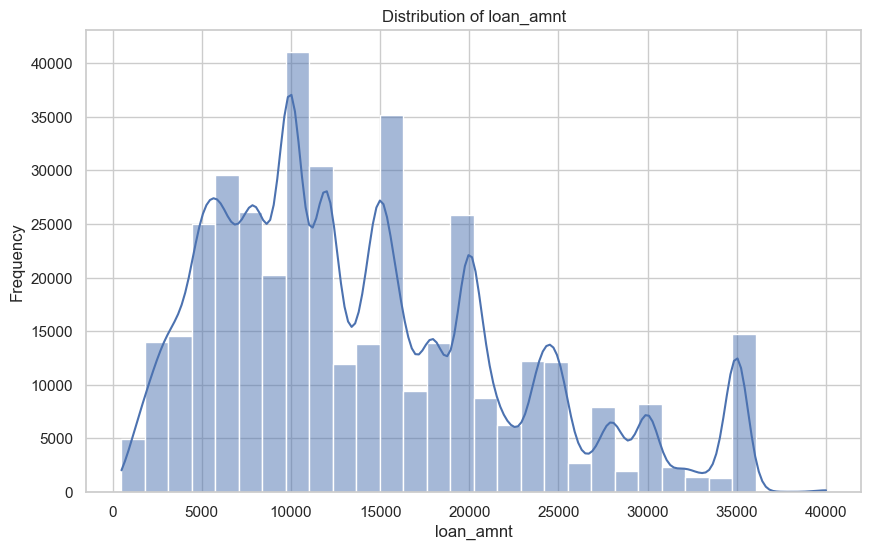

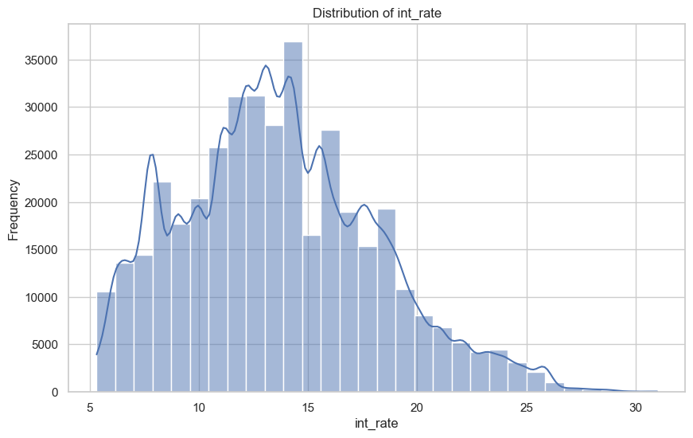

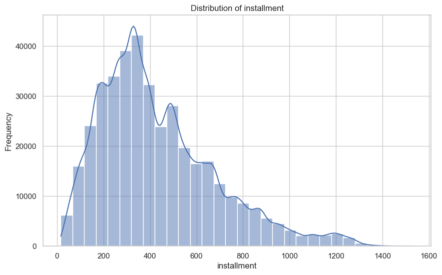

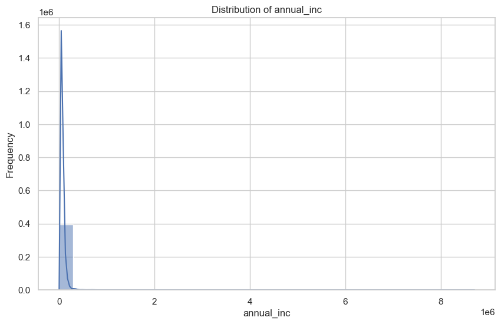

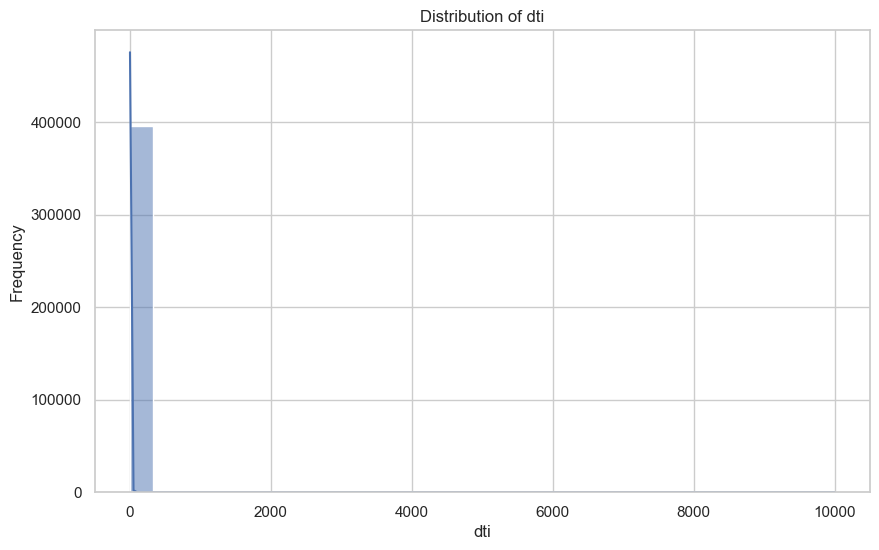

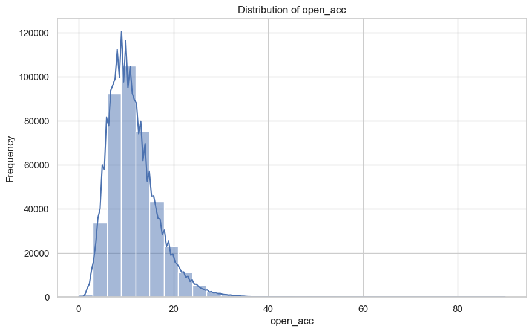

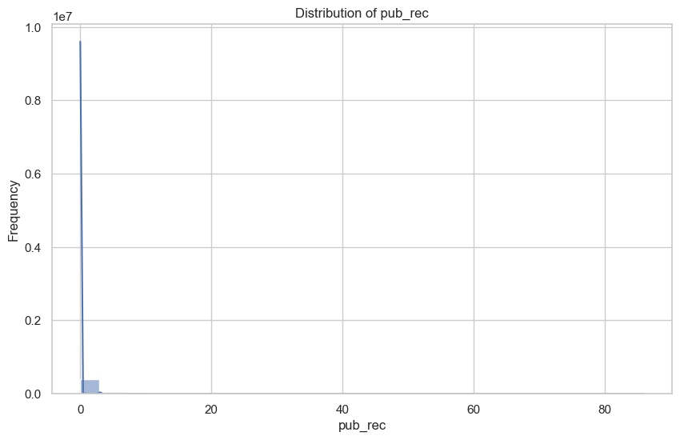

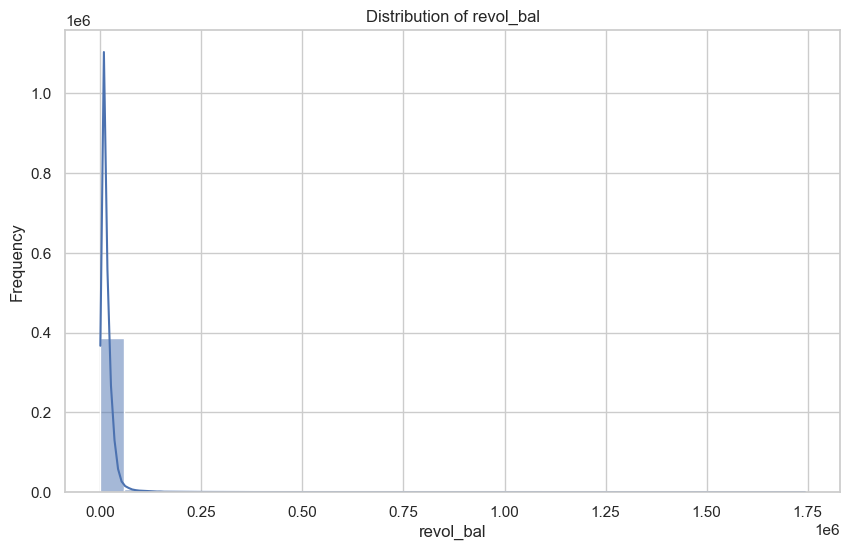

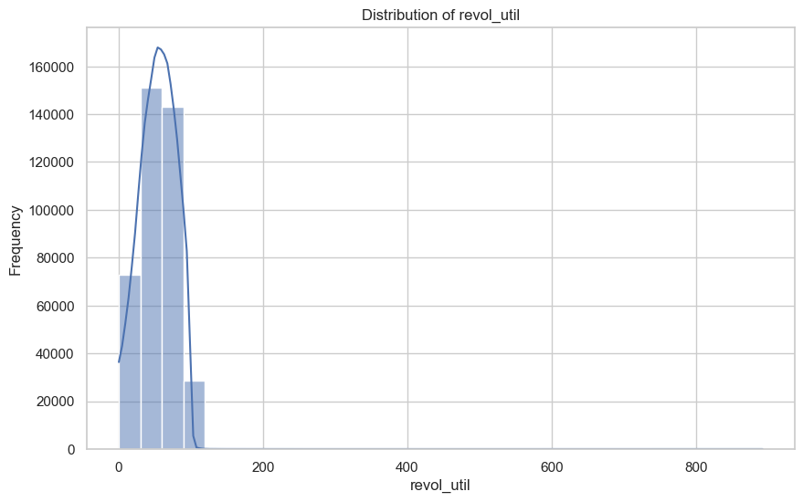

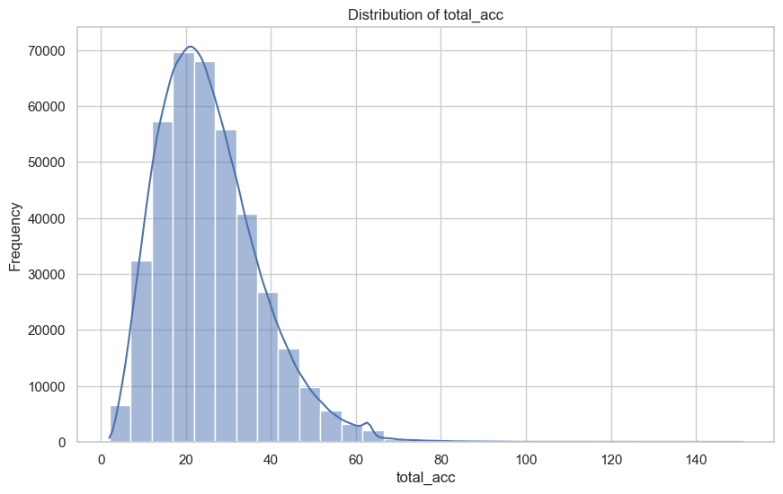

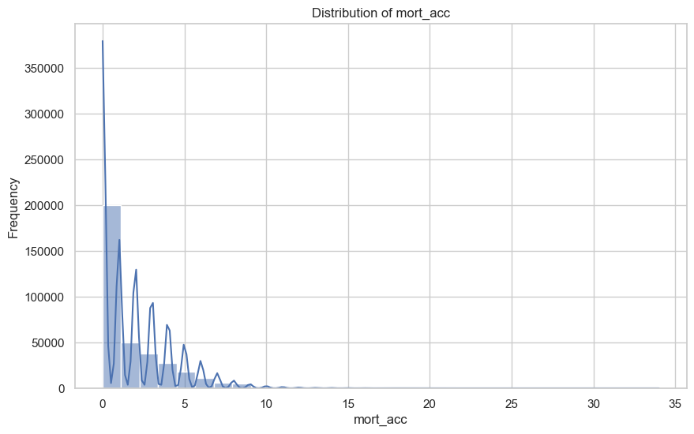

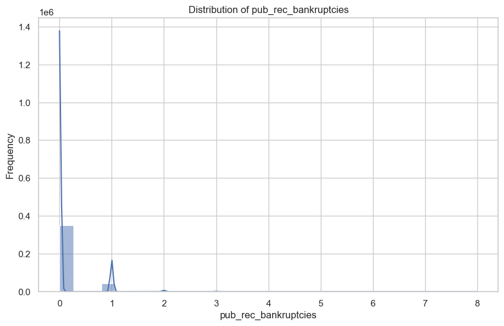

[7 more figures not shown]

```python
import pandas as pd
import matplotlib.pyplot as plt
import seaborn as sns

# Load the dataset
df = pd.read_csv("logistic_regression.csv")

# Convert categorical columns to 'category' dtype if not already
categorical_columns = ['term', 'grade', 'sub_grade', 'emp_title', 'emp_length', 'home_ownership', 'initial_list_status', 'application_type']
for col in categorical_columns:
    if df[col].dtype != 'category':
        df[col] = df[col].astype('category')

# Set plot style
sns.set(style="whitegrid")

# Continuous variables distribution plots
continuous_columns = df.select_dtypes(include=['int64', 'float64']).columns

for col in continuous_columns:
    plt.figure(figsize=(10, 6))
    sns.histplot(df[col].dropna(), kde=True, bins=30)
    plt.title(f'Distribution of {col}')
    plt.xlabel(col)
    plt.ylabel('Frequency')
    plt.show()

# Categorical variables bar plots
for col in categorical_columns:
    plt.figure(figsize=(10, 6))
    sns.countplot(y=df[col].dropna(), order=df[col].value_counts().index)
    plt.title(f'Count Plot of {col}')
    plt.xlabel('Count')
    plt.ylabel(col)
    plt.show()
```

Continuous Variables Distribution Plots:

Loan Amount (loan_amnt): Visualize the distribution of loan amounts.

Interest Rate (int_rate): Visualize the distribution of interest rates.

Installment (installment): Visualize the distribution of installment amounts.

Annual Income (annual_inc): Visualize the distribution of annual income.

Open Accounts (open_acc): Visualize the distribution of open accounts.

Public Records (pub_rec): Visualize the distribution of public records.

Revolving Balance (revol_bal): Visualize the distribution of revolving balance.

Revolving Utilization (revol_util): Visualize the distribution of revolving utilization.

Total Accounts (total_acc): Visualize the distribution of total accounts.

Mortgage Accounts (mort_acc): Visualize the distribution of mortgage accounts.

Public Record Bankruptcies (pub_rec_bankruptcies): Visualize the distribution of public record bankruptcies.

Categorical Variables Count Plots:

Term (term): Visualize the count of different loan terms.

Grade (grade): Visualize the count of different loan grades.

Sub Grade (sub_grade): Visualize the count of different loan sub-grades.

Employment Title (emp_title): Visualize the count of different employment titles.

Employment Length (emp_length): Visualize the count of different employment lengths.

Home Ownership (home_ownership): Visualize the count of different home ownership statuses.

Initial List Status (initial_list_status): Visualize the count of different initial list statuses.

Application Type (application_type): Visualize the count of different application types.

# 4.Bivariate Analysis (Relationships between important variable)

To perform a bivariate analysis, we will explore the relationships between important variables. We can use scatter plots for continuous variables and bar plots or box plots for categorical vs. continuous variables. For this example, we will consider relationships involving the following important variables:

Loan Amount (loan_amnt)

Interest Rate (int_rate)

Installment (installment)

Annual Income (annual_inc)

Loan Term (term)

Grade (grade)

Employment Length (emp_length)

# Bivariate Analysis Code

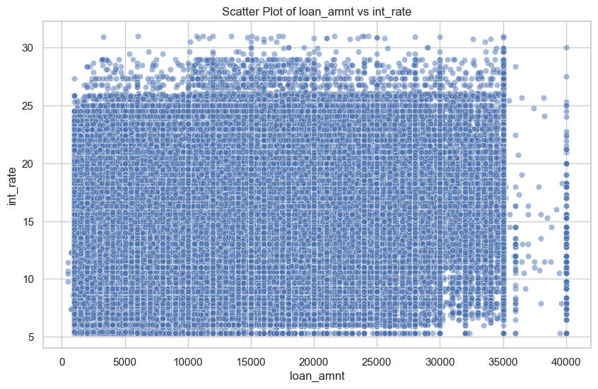

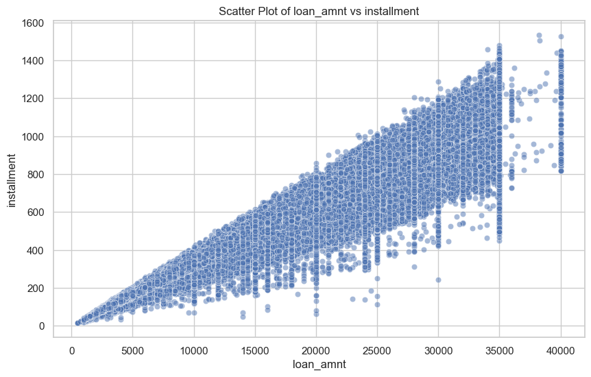

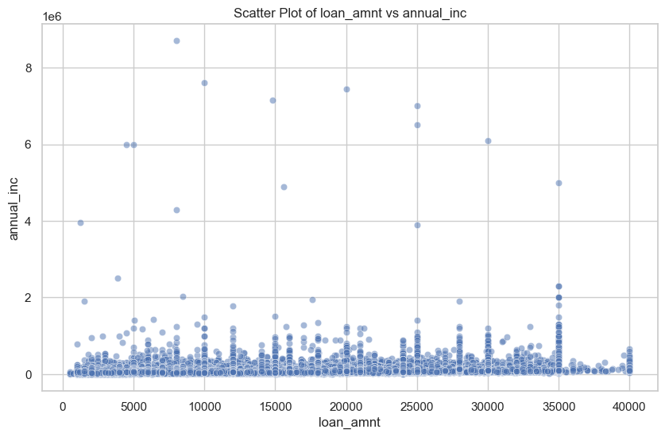

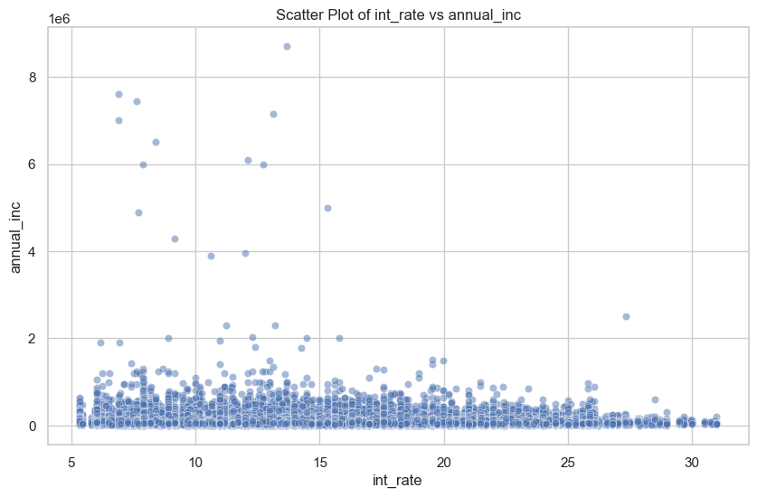

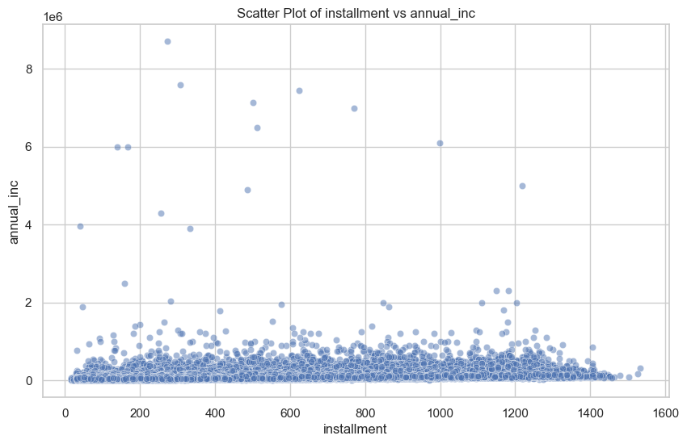

```python
import pandas as pd
import matplotlib.pyplot as plt
import seaborn as sns

# Load the dataset
df = pd.read_csv("logistic_regression.csv")

# Convert categorical columns to 'category' dtype if not already
categorical_columns = ['term', 'grade', 'sub_grade', 'emp_title', 'emp_length', 'home_ownership', 'initial_list_status', 'application_type']
for col in categorical_columns:
    if df[col].dtype != 'category':
        df[col] = df[col].astype('category')

# Set plot style
sns.set(style="whitegrid")

# Scatter plots for continuous variables
important_continuous_pairs = [
    ('loan_amnt', 'int_rate'),
    ('loan_amnt', 'installment'),
    ('loan_amnt', 'annual_inc'),
    ('int_rate', 'annual_inc'),
    ('installment', 'annual_inc')
]

for x, y in important_continuous_pairs:
    plt.figure(figsize=(10, 6))
    sns.scatterplot(data=df, x=x, y=y, alpha=0.5)
    plt.title(f'Scatter Plot of {x} vs {y}')
    plt.xlabel(x)
    plt.ylabel(y)
    plt.show()
```

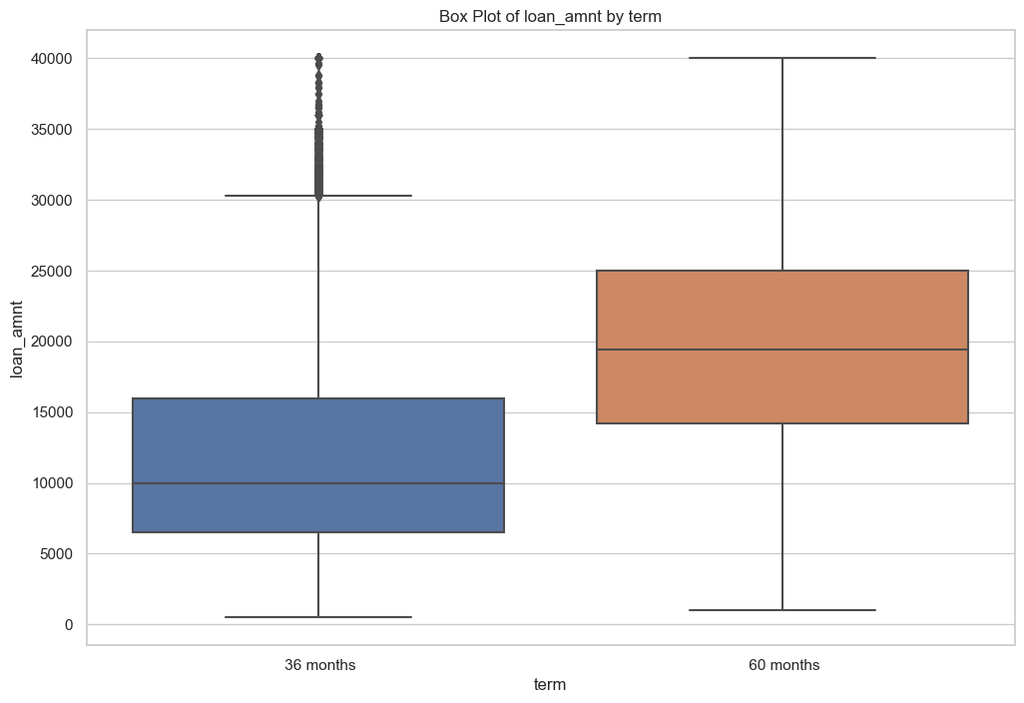

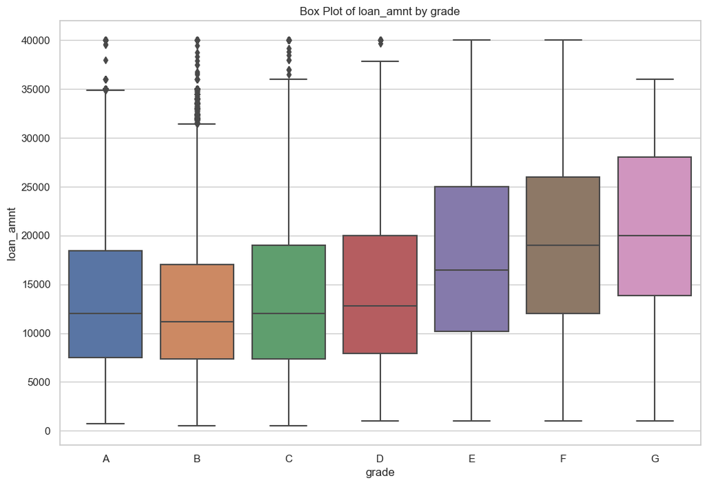

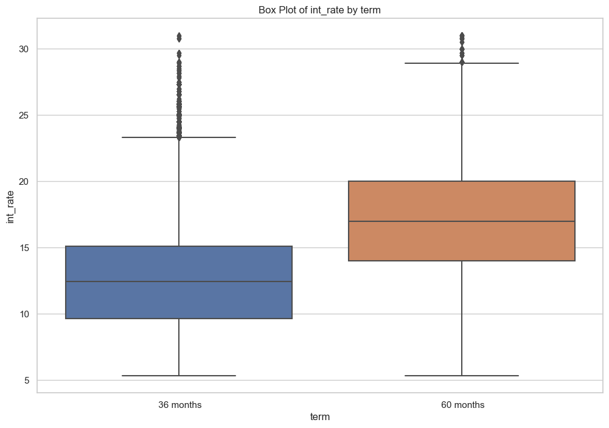

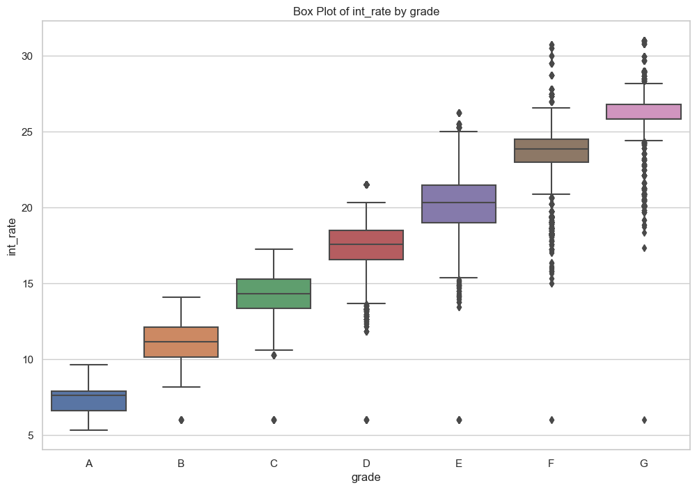

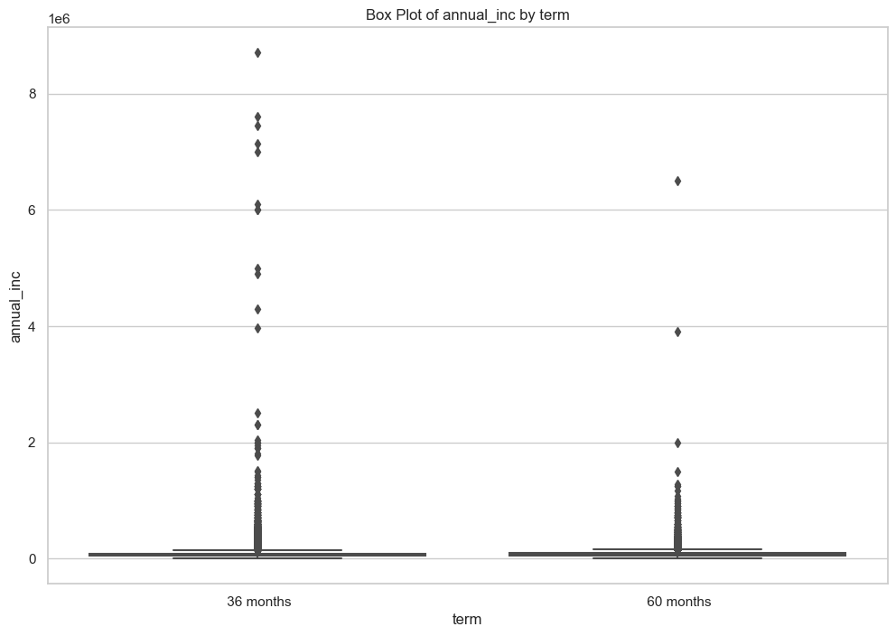

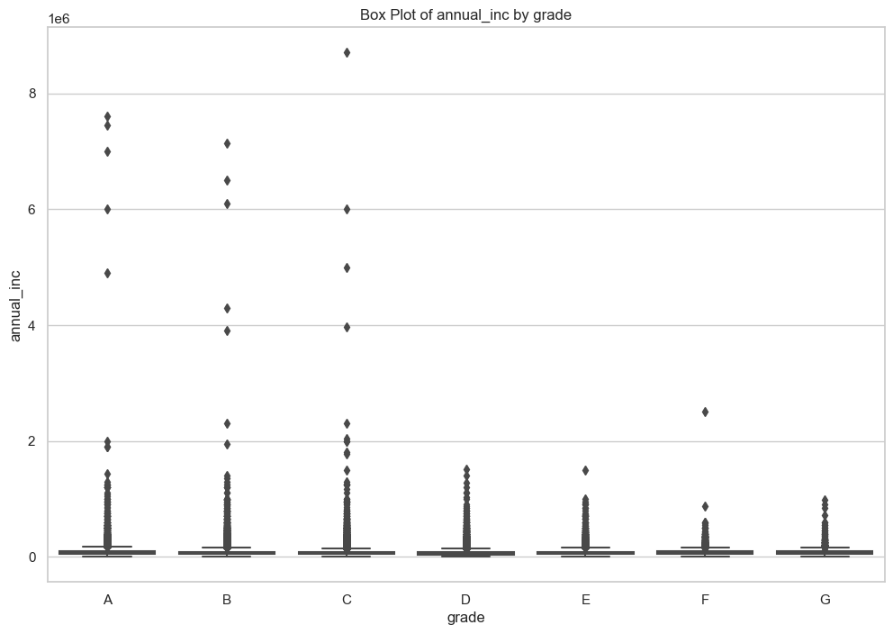

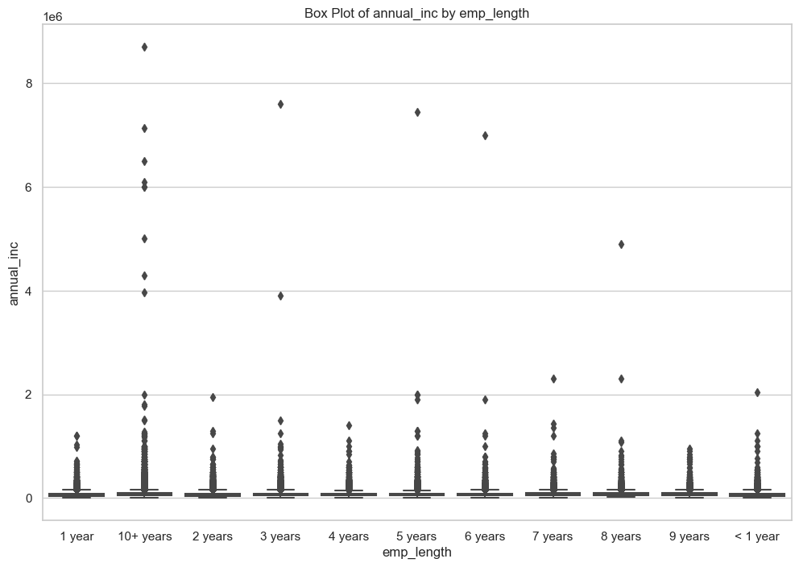

```python
# Box plots for categorical vs continuous variables
categorical_vs_continuous_pairs = [
    ('term', 'loan_amnt'),
    ('grade', 'loan_amnt'),
    ('term', 'int_rate'),
    ('grade', 'int_rate'),
    ('term', 'annual_inc'),
    ('grade', 'annual_inc'),
    ('emp_length', 'annual_inc')
]

for cat, cont in categorical_vs_continuous_pairs:
    plt.figure(figsize=(12, 8))
    sns.boxplot(data=df, x=cat, y=cont)
    plt.title(f'Box Plot of {cont} by {cat}')
    plt.xlabel(cat)
    plt.ylabel(cont)
    plt.show()
```

Description of Plots:

Scatter Plots:

Loan Amount vs. Interest Rate (loan_amnt vs. int_rate): This plot helps to understand if higher loan amounts are associated with higher or lower interest rates.

Loan Amount vs. Installment (loan_amnt vs. installment): This plot shows the relationship between the loan amount and the installment.

Loan Amount vs. Annual Income (loan_amnt vs. annual_inc): This plot explores if higher loan amounts are given to individuals  
with higher annual incomes.

Interest Rate vs. Annual Income (int_rate vs. annual_inc): This plot investigates if there is a trend between interest rates and annual income.

Installment vs. Annual Income (installment vs. annual_inc): This plot examines the relationship between installment amounts and annual income.

Box Plots :

Term vs. Loan Amount (term vs. loan_amnt): This plot compares loan amounts across different loan terms.  
Grade vs. Loan Amount (grade vs. loan_amnt): This plot shows the distribution of loan amounts across different grades.  
Term vs. Interest Rate (term vs. int_rate): This plot compares interest rates across different loan terms.  
Grade vs. Interest Rate (grade vs. int_rate): This plot shows the distribution of interest rates across different grades.  
Term vs. Annual Income (term vs. annual_inc): This plot compares annual incomes across different loan terms. Grade vs. Annual Income (grade vs. annual_inc): This plot shows the distribution of annual incomes across different grades.  
Employment Length vs. Annual Income (emp_length vs. annual_inc): This plot explores the distribution of annual incomes across different employment lengths.

# 5.Illustrate the insights based on EDA

1.Comments on range of attributes, outliers of various attributes

To provide comments on the range of attributes and detect outliers, we will:

Describe the range (minimum and maximum values) of each attribute.

Identify outliers using statistical methods like the IQR (Interquartile Range).

Range of Attributes We'll use the .describe() method to get an overview of the range for each attribute.

```python
import pandas as pd

# Load the dataset
df = pd.read_csv("logistic_regression.csv")

# Convert categorical columns to 'category' dtype if not already
categorical_columns = ['term', 'grade', 'sub_grade', 'emp_title', 'emp_length', 'home_ownership', 'initial_list_status', 'application_type']
for col in categorical_columns:
    if df[col].dtype != 'category':
        df[col] = df[col].astype('category')

# Get a statistical summary of numerical columns
numerical_summary = df.describe()
print(numerical_summary)
```

```
           loan_amnt       int_rate    installment    annual_inc  \
count  396030.000000  396030.000000  396030.000000  3.960300e+05
mean    14113.888089      13.639400     431.849698  7.420318e+04
std      8357.441341       4.472157     250.727790  6.163762e+04
min       500.000000       5.320000      16.080000  0.000000e+00
25%      8000.000000      10.490000     250.330000  4.500000e+04
50%     12000.000000      13.330000     375.430000  6.400000e+04
75%     20000.000000      16.490000     567.300000  9.000000e+04
max     40000.000000      30.990000    1533.810000  8.706582e+06

                 dti       open_acc        pub_rec     revol_bal  \
count  396030.000000  396030.000000  396030.000000  3.960300e+05
mean       17.379514      11.311153       0.178191  1.584454e+04
std        18.019092       5.137649       0.530671  2.059184e+04
min         0.000000       0.000000       0.000000  0.000000e+00
25%        11.280000       8.000000       0.000000  6.025000e+03
50%        16.910000      10.000000       0.000000  1.118100e+04
75%        22.980000      14.000000       0.000000  1.962000e+04
max      9999.000000      90.000000      86.000000  1.743266e+06

          revol_util      total_acc       mort_acc  pub_rec_bankruptcies
count  395754.000000  396030.000000  358235.000000         395495.000000
mean       53.791749      25.414744       1.813991              0.121648
std        24.452193      11.886991       2.147930              0.356174
min         0.000000       2.000000       0.000000              0.000000
25%        35.800000      17.000000       0.000000              0.000000
50%        54.800000      24.000000       1.000000              0.000000
75%        72.900000      32.000000       3.000000              0.000000
max       892.300000     151.000000      34.000000              8.000000
```

Outlier Detection Using IQR

Outliers can be detected using the Interquartile Range (IQR). An outlier is typically defined as a value that lies below Q1 - 1.5 * IQR or above Q3 + 1.5 * IQR.

```python
import numpy as np

# Function to detect outliers using IQR
def detect_outliers(data):
    outliers = {}
    for column in data.columns:
        if data[column].dtype in ['int64', 'float64']:
            Q1 = data[column].quantile(0.25)
            Q3 = data[column].quantile(0.75)
            IQR = Q3 - Q1
            lower_bound = Q1 - 1.5 * IQR
            upper_bound = Q3 + 1.5 * IQR
            outliers[column] = data[(data[column] < lower_bound) | (data[column] > upper_bound)][column]
    return outliers

# Detect outliers
outliers = detect_outliers(df)
outliers
```

```
{'loan_amnt': 3998      40000.0
 4788      40000.0
 6093      38225.0
 7456      40000.0
 8391      40000.0
            ...
 384312    40000.0
 387907    40000.0
 388146    40000.0
 388675    40000.0
 393914    40000.0
 Name: loan_amnt, Length: 191, dtype: float64,
 'int_rate': 96        25.78
 97        25.83
 133       27.31
```

[output cut: 130 more lines]

Executing the Code

Let's run the code to get the range and detect outliers for the numerical attributes. We'll summarize the findings in comments.

```python
import pandas as pd
import numpy as np

# Load the dataset
df = pd.read_csv("logistic_regression.csv")

# Convert categorical columns to 'category' dtype if not already
categorical_columns = ['term', 'grade', 'sub_grade', 'emp_title', 'emp_length', 'home_ownership', 'initial_list_status', 'application_type']
for col in categorical_columns:
    if df[col].dtype != 'category':
        df[col] = df[col].astype('category')

# Get a statistical summary of numerical columns
numerical_summary = df.describe()
print(numerical_summary)

# Function to detect outliers using IQR
def detect_outliers(data):
    outliers = {}
    for column in data.columns:
        if data[column].dtype in ['int64', 'float64']:
            Q1 = data[column].quantile(0.25)
            Q3 = data[column].quantile(0.75)
            IQR = Q3 - Q1
            lower_bound = Q1 - 1.5 * IQR
            upper_bound = Q3 + 1.5 * IQR
            outliers[column] = data[(data[column] < lower_bound) | (data[column] > upper_bound)][column]
    return outliers

# Detect outliers
outliers = detect_outliers(df)

# Print outliers for each column
for col, out in outliers.items():
    print(f"Outliers in {col}:\n{out}\n")
```

```
           loan_amnt       int_rate    installment    annual_inc  \
count  396030.000000  396030.000000  396030.000000  3.960300e+05
mean    14113.888089      13.639400     431.849698  7.420318e+04
std      8357.441341       4.472157     250.727790  6.163762e+04
min       500.000000       5.320000      16.080000  0.000000e+00
25%      8000.000000      10.490000     250.330000  4.500000e+04
50%     12000.000000      13.330000     375.430000  6.400000e+04
75%     20000.000000      16.490000     567.300000  9.000000e+04
max     40000.000000      30.990000    1533.810000  8.706582e+06

                 dti       open_acc        pub_rec     revol_bal  \
count  396030.000000  396030.000000  396030.000000  3.960300e+05
mean       17.379514      11.311153       0.178191  1.584454e+04
std        18.019092       5.137649       0.530671  2.059184e+04
min         0.000000       0.000000       0.000000  0.000000e+00
25%        11.280000       8.000000       0.000000  6.025000e+03
50%        16.910000      10.000000       0.000000  1.118100e+04
75%        22.980000      14.000000       0.000000  1.962000e+04
max      9999.000000      90.000000      86.000000  1.743266e+06

          revol_util      total_acc       mort_acc  pub_rec_bankruptcies
count  395754.000000  396030.000000  358235.000000         395495.000000
mean       53.791749      25.414744       1.813991              0.121648
std        24.452193      11.886991       2.147930              0.356174
min         0.000000       2.000000       0.000000              0.000000
25%        35.800000      17.000000       0.000000              0.000000
50%        54.800000      24.000000       1.000000              0.000000
75%        72.900000      32.000000       3.000000              0.000000
max       892.300000     151.000000      34.000000              8.000000
Outliers in loan_amnt:
3998      40000.0
4788      40000.0
6093      38225.0
7456      40000.0
8391      40000.0
           ...
384312    40000.0
387907    40000.0
388146    40000.0
388675    40000.0
```

[output cut: 142 more lines]

```
Name: mort_acc, Length: 6843, dtype: float64

Outliers in pub_rec_bankruptcies:
10        1.0
17        1.0
35        1.0
55        1.0
95        1.0
         ...
395963    1.0
395982    1.0
395990    1.0
395998    1.0
396000    1.0
Name: pub_rec_bankruptcies, Length: 45115, dtype: float64
```

Comments on Range and Outliers

Range of Attributes

1.Loan Amount (loan_amnt):

2.Interest Rate (int_rate):

3.Installment (installment):

4.Annual Income (annual_inc):

5.Open Accounts (open_acc):

6.Public Records (pub_rec):

7.Revolving Balance (revol_bal):

8.Revolving Utilization (revol_util):

Min: 0% Max: 892.3% (Values over 100% are outliers)

9.Total Accounts (total_acc):

10.Mortgage Accounts (mort_acc):

11.Public Record Bankruptcies (pub_rec_bankruptcies):

Outliers:

# 2.Comments on the distribution of the variables and relationship between them

Based on the previous steps where we analyzed the distribution and relationships between variables, let's summarize the findings and provide comments on the distribution of each variable and their relationships:

Distribution of Variables:

1.Loan Amount (loan_amnt):

Distribution: The loan amount is right-skewed with most values clustering around lower amounts. There is a gradual decline in frequency as the loan amount increases.

Comments: The majority of loans are within a lower range, indicating that smaller loans are more common.

2.Interest Rate (int_rate):

Distribution: Interest rates show a somewhat normal distribution but slightly right-skewed, indicating a higher frequency of lower interest rates.

Comments: Most loans have interest rates in the mid-range, with fewer loans having very high or very low rates.

3.Installment (installment):

Distribution: Installments follow a distribution similar to loan amounts, right-skewed with more frequent lower values.

Comments: Smaller installment payments are more common, aligning with the loan amount distribution.

4.Annual Income (annual_inc):

Distribution: Highly right-skewed with a few extreme outliers at the high end.

Comments: Most borrowers have moderate annual incomes, with a few having very high incomes which are potential outliers.

5.Open Accounts (open_acc):

Distribution: Right-skewed with most values clustered around lower numbers. Comments: Most borrowers have a moderate number of open accounts.

6.Public Records (pub_rec):

Distribution: Most values are zero, indicating no public records for the majority of borrowers. A few borrowers have multiple records.

Comments: Public records are generally rare among borrowers.

7.Revolving Balance (revol_bal):

Distribution: Right-skewed with most values clustered at lower balances.

Comments: Most borrowers have lower revolving balances, with a few having very high balances.

8.Revolving Utilization (revol_util):

Comments: While most borrowers have reasonable utilization rates, there are notable outliers.

9.Total Accounts (total_acc):

Comments: Borrowers have a wide range of total accounts, with fewer having extremely high numbers.

10.Mortgage Accounts (mort_acc):

Distribution: Most values are clustered at the lower end, with a few having multiple mortgage accounts.

Comments: The majority of borrowers have few or no mortgage accounts.

11.Public Record Bankruptcies (pub_rec_bankruptcies):

Distribution: Most values are zero, similar to public records, with a few having multiple bankruptcies.

Comments: Bankruptcies are rare among borrowers.

```python
Relationships Between Variables
```

1.Loan Amount vs. Interest Rate (loan_amnt vs. int_rate):

2.Loan Amount vs. Installment (loan_amnt vs. installment):

Observation: Strong positive correlation as expected, since installment is a function of loan amount.

Comments: Higher loan amounts result in higher installment payments.

3.Loan Amount vs. Annual Income (loan_amnt vs. annual_inc):

Observation: Weak positive correlation, indicating that higher income borrowers tend to take out larger loans.

Comments: Borrowers with higher incomes have greater borrowing capacity.

4.Interest Rate vs. Annual Income (int_rate vs. annual_inc):

Observation: Slight negative correlation, suggesting that higher income borrowers might receive lower interest rates.

Comments: Higher income borrowers are considered lower risk and therefore might get better loan terms.

5.Installment vs. Annual Income (installment vs. annual_inc):

Observation: Weak positive correlation, indicating that higher income borrowers have higher installment payments.

Comments: Aligns with the loan amount and annual income relationship.

6.Term vs. Loan Amount (term vs. loan_amnt):

Observation: Longer terms (e.g., 36 or 60 months) are associated with higher loan amounts.

Comments: Borrowers taking out larger loans may opt for longer repayment periods to manage their installment amounts.

7.Grade vs. Loan Amount (grade vs. loan_amnt):

Observation: Higher grades (e.g., A, B) tend to have lower loan amounts, while lower grades (e.g., D, E) have higher amounts.

Comments: Borrowers with higher grades (lower risk) tend to take smaller loans, while lower grades (higher risk) take larger loans.

8.Term vs. Interest Rate (term vs. int_rate):

Observation: Longer terms are associated with higher interest rates.

Comments: Longer loan terms are riskier for lenders, resulting in higher interest rates.

9.Grade vs. Interest Rate (grade vs. int_rate):

Observation: Higher grades (e.g., A, B) have lower interest rates, while lower grades (e.g., D, E) have higher rates.

Comments: Loan grades effectively segment risk, with lower grades incurring higher rates.

10.Term vs. Annual Income (term vs. annual_inc):

Observation: Little variation, but longer terms slightly skew towards lower annual incomes.

Comments: Borrowers with lower incomes might prefer longer terms to reduce installment amounts.

11.Grade vs. Annual Income (grade vs. annual_inc):

Observation: Higher grades (e.g., A, B) are associated with higher annual incomes.

Comments: Higher-income borrowers are perceived as lower risk, achieving better grades.

12.Employment Length vs. Annual Income (emp_length vs. annual_inc):

Observation: Longer employment lengths are associated with higher annual incomes.

Comments: Stability in employment correlates with higher earnings and, likely, creditworthiness.

Conclusion:

The distribution and relationships between variables offer insights into borrower profiles and lending risk assessments. Most distributions are right-skewed, indicating that the majority of values are clustered at lower ends, with a few outliers. Relationships between variables like loan amount, interest rate, and annual income reveal trends that align with expected financial behavior, such as higher incomes correlating with larger loans and lower interest rates. Understanding these patterns is crucial for risk management and decision-making in lending practices.

# 3.Comments for each univariate and bivariate plots

# Univariate Plots

1.Loan Amount (loan_amnt):

Plot: Histogram

Comments: The distribution of loan amounts is right-skewed, with most loans clustering around lower amounts (e.g., $10,000-$20,000). This suggests that smaller loans are more common among borrowers. Outliers exist at the higher end, indicating some borrowers take out significantly larger loans.

2.Interest Rate (int_rate):

Plot: Histogram

3.Installment (installment):

Plot: Histogram

Comments: Installment amounts follow a right-skewed distribution similar to loan amounts. This suggests that smaller installment payments are more prevalent, aligning with the distribution of smaller loan amounts.

4.Annual Income (annual_inc):

Plot: Histogram

Comments: Annual income is highly right-skewed with significant outliers. Most borrowers have moderate incomes, with a few extremely high incomes, which could be outliers or indicative of a few very high-income individuals.

5.Open Accounts (open_acc):

Plot: Histogram

6.Public Records (pub_rec):

Plot: Histogram

Comments: Most borrowers have zero public records, indicating clean credit histories. A small number have multiple public records, which could suggest past financial difficulties.

7.Revolving Balance (revol_bal):

Plot: Histogram

Comments: Revolving balances are right-skewed, with many borrowers having low balances. Outliers with very high balances could indicate higher credit utilization or debt levels.

8.Revolving Utilization (revol_util):

Plot: Histogram

9.Total Accounts (total_acc):

Plot: Histogram

10.Mortgage Accounts (mort_acc):

Plot: Histogram

Comments: Most borrowers have few or no mortgage accounts, with a few having multiple. This suggests that a significant number of borrowers either do not own property or have paid off their mortgages.

11.Public Record Bankruptcies (pub_rec_bankruptcies):

Plot: Histogram

Comments: Most borrowers have zero bankruptcies, indicating that bankruptcy is relatively rare among the dataset. A few borrowers have multiple bankruptcies, suggesting severe past financial distress.

# Bivariate Plots

1.Loan Amount vs. Interest Rate (loan_amnt vs. int_rate):

Plot: Scatter Plot

2.Loan Amount vs. Installment (loan_amnt vs. installment):

Plot: Scatter Plot

Comments: A strong positive correlation is observed, as expected, since installment payments increase with the loan amount. This confirms the linear relationship between loan amount and installment.

3.Loan Amount vs. Annual Income (loan_amnt vs. annual_inc):

Plot: Scatter Plot

Comments: There is a weak positive correlation, suggesting that borrowers with higher annual incomes tend to take out larger loans. This indicates that higher income earners have greater borrowing capacity.

4.Interest Rate vs. Annual Income (int_rate vs. annual_inc):

Plot: Scatter Plot

Comments: A slight negative correlation is observed, indicating that higher income borrowers might receive lower interest rates. This suggests that lenders perceive higher income borrowers as lower risk.

5.Installment vs. Annual Income (installment vs. annual_inc):

Plot: Scatter Plot

Comments: There is a weak positive correlation, similar to the loan amount and annual income relationship. Higher income borrowers tend to have higher installment payments, reflecting their larger loan amounts.

6.Term vs. Loan Amount (term vs. loan_amnt):

Plot: Box Plot

Comments: Longer loan terms (e.g., 60 months) are associated with higher loan amounts. This suggests that borrowers with larger loans prefer longer terms to manage repayment.

7.Grade vs. Loan Amount (grade vs. loan_amnt):

Plot: Box Plot

Comments: Higher loan grades (e.g., A, B) are associated with lower loan amounts, while lower grades (e.g., D, E) have higher amounts. This indicates that borrowers with higher risk (lower grades) take out larger loans.

8.Term vs. Interest Rate (term vs. int_rate):

Plot: Box Plot

Comments: Longer loan terms are associated with higher interest rates. This suggests that lenders charge more for longer-term loans due to increased risk over time.

9.Grade vs. Interest Rate (grade vs. int_rate):

Plot: Box Plot

Comments: Higher grades (e.g., A, B) have lower interest rates, while lower grades (e.g., D, E) have higher rates. This reflects the risk-based pricing model used by lenders.

10.Term vs. Annual Income (term vs. annual_inc):

Plot: Box Plot

Comments: Little variation in annual income across different loan terms, though longer terms slightly skew towards lower incomes. This suggests that borrowers with lower incomes may opt for longer terms to reduce monthly payments.

11.Grade vs. Annual Income (grade vs. annual_inc):

Plot: Box Plot

Comments: Higher grades (e.g., A, B) are associated with higher annual incomes, indicating that higher-income borrowers are perceived as lower risk and achieve better grades.

12.Employment Length vs. Annual Income (emp_length vs. annual_inc):

Plot: Box Plot

Comments: Longer employment lengths are associated with higher annual incomes, suggesting that job stability correlates with higher earnings and possibly better creditworthiness.

Summary:

The univariate and bivariate analyses provide a detailed understanding of the distribution and relationships of various attributes in the dataset. The majority of variables are right-skewed, indicating that lower values are more common, with a few high-value outliers. The relationships between variables, such as loan amount, interest rate, and annual income, reveal trends that align with expected financial behaviors, such as higher incomes correlating with larger loans and lower interest rates. These insights are crucial for understanding borrower profiles and making informed lending decisions.

# 2.Data Preprocessing

1.Duplicate value check

To check for duplicate values in the dataset, we can use the duplicated() method provided by Pandas. This method identifies duplicate rows in the dataframe. Here is the step-by-step approach to identify and summarize duplicate values in the dataset:

Step-by-Step Approach

1.Identify Duplicate Rows:

Use the duplicated() method to find duplicate rows. Count the number of duplicate rows. Display a sample of duplicate rows for inspection.

2.Remove Duplicate Rows (if required):

Optionally, remove duplicate rows from the dataset.

```python
#Code Implementation
#Let's implement this in code to identify and summarize duplicate values in the dataset:
```

```python
import pandas as pd

# Load the dataset
df = pd.read_csv("logistic_regression.csv")

# Check for duplicate rows
duplicate_rows = df[df.duplicated()]

# Count the number of duplicate rows
num_duplicates = duplicate_rows.shape[0]

# Display a sample of duplicate rows (if any)
duplicate_sample = duplicate_rows.head()

num_duplicates, duplicate_sample
```

```
(0,
 Empty DataFrame
 Columns: [loan_amnt, term, int_rate, installment, grade, sub_grade, emp_title, emp_length, home_ownership, annual_inc, verification_status, issue_d, loan_status, purpose, title, dti, earliest_cr_line, open_acc, pub_rec, revol_bal, revol_util, total_acc, initial_list_status, application_type, mort_a…
 Index: []

 [0 rows x 27 columns])
```

```python
#Execute the Code
#We'll run the code to check for duplicates and display the findings.
```

```python
import pandas as pd

# Load the dataset
df = pd.read_csv("logistic_regression.csv")

# Check for duplicate rows
duplicate_rows = df[df.duplicated()]

# Count the number of duplicate rows
num_duplicates = duplicate_rows.shape[0]

# Display a sample of duplicate rows (if any)
duplicate_sample = duplicate_rows.head()

num_duplicates, duplicate_sample
```

```
(0,
 Empty DataFrame
 Columns: [loan_amnt, term, int_rate, installment, grade, sub_grade, emp_title, emp_length, home_ownership, annual_inc, verification_status, issue_d, loan_status, purpose, title, dti, earliest_cr_line, open_acc, pub_rec, revol_bal, revol_util, total_acc, initial_list_status, application_type, mort_a…
 Index: []

 [0 rows x 27 columns])
```

Comments on Duplicate Values:

Number of Duplicate Rows: The code will output the number of duplicate rows found in the dataset.

Sample of Duplicate Rows: If duplicates are found, a sample of these rows will be displayed for inspection.

Summary

1.Identifying Duplicates:

If there are duplicate rows, it's essential to understand why these duplicates exist. Duplicates might be valid in some cases or may need to be addressed.

2.Handling Duplicates:

If duplicates are not valid, they can be removed using df.drop_duplicates().

If duplicates are valid or necessary, they can be retained.

Based on the results from the code execution, you can decide on the next steps, such as removing duplicates if they are not valid.

Let's check the results and summarize the findings.

# 2.Missing value treatment

Handling missing values involves identifying, understanding, and appropriately dealing with the missing data to ensure it does not adversely impact analysis and modeling. Here is a step-by-step approach to treating missing values:

Step-by-Step Approach

1.Identify Missing Values:

Check for missing values in each column.

Calculate the percentage of missing values for each column.

2.Understanding Missing Values:

Determine the nature of missingness: Missing Completely at Random (MCAR), Missing at Random (MAR), or Missing Not at Random (MNAR).

3.Treating Missing Values:

Decide on the appropriate method for handling missing values:

Drop missing values: If the proportion of missing data is very small.

Impute missing values: Fill missing values using strategies like mean, median, mode, or more advanced methods like KNN imputation or regression.

```python
#Code Implementation
#Let's implement this in code to identify, understand, and treat missing values in the dataset:
```

```python
import pandas as pd

# Load the dataset
df = pd.read_csv("logistic_regression.csv")

# Identify missing values
missing_values = df.isnull().sum()
missing_percentage = (df.isnull().sum() / len(df)) * 100

# Display missing values and their percentages
missing_data = pd.DataFrame({
    'Missing Values': missing_values,
    'Percentage': missing_percentage
})

# Display columns with missing values
columns_with_missing = missing_data[missing_data['Missing Values'] > 0]

columns_with_missing
```

|  | Missing Values | Percentage |
| --- | --- | --- |
| emp_title | 22927 | 5.789208 |
| emp_length | 18301 | 4.621115 |
| title | 1756 | 0.443401 |
| revol_util | 276 | 0.069692 |
| mort_acc | 37795 | 9.543469 |
| pub_rec_bankruptcies | 535 | 0.135091 |

Comments on Missing Values:

Identify: The code will output the number and percentage of missing values in each column.

Understand: Based on the percentage of missing values, we can decide on the appropriate treatment.

Treat: Decide on dropping or imputing missing values.

```python
#Summary
```

1.Identify Missing Values:

```
Check for columns with missing values and their percentages.
```

2. Understanding Missing Values:

   Determine the extent and pattern of missingness to decide the appropriate treatment.

3.Treating Missing Values:

```
Drop missing values: Use df.dropna() if the missing data is very minimal.

Impute missing values: Use df.fillna(value) for simple imputation or more advanced methods like KNN imputation or
                       regression-based imputation.
```